# PPC Model

````r
```r
##################################################
#  Monte Carlo Simulation v2.0p
##################################################
## Project: Dairy Spoilage Model
## Script purpose: Simulate PPC for half gallon samples of milk
##                 over a given number of days.
## THIS IS EDITED TO VALIDATE THE VSL DATA. DO NOT USE THIS AS THE FINAL VERSION OF CODE
##################################################
## Notes: This version forks from V2.0 of the Psychrotolerant
##        Sporeformer Predictive Model and will be used by Samantha Lau
##        to create a PPC model
#Edited by SL on 01-29-20
##################################################
````

````r
```r

#use a seed value for reproducibility
seed_value = 42;    #can be any number
````

- Include all library packages that need to be downloaded and used

```r
library(splitstackshape)
library(dplyr)
library(ggplot2)
library(readr)
library(MASS)
```

## Utility Functions

- muAtNewTemp
  - Purpose: Calculate the new mu parameter at new temperature.
  - Params:
    - newTemp: the new temperature for which we calculate mu
    - oldMu: the previous mu value to adjust
    - oldTemp: the temperature corresponding to previous mu
    - T0: parameter used to calculate new mu
    - This uses the Ratkowsky square model which describes the effect of temperature on the growth of microorganisms
    - The paper it comes from: https://www.ncbi.nlm.nih.gov/pubmed/22417595
    - Sam checked equation and it is correct
    - The T0 is estimate dto be -3.62C based on growth curves of Paenibacillus ordorifer obtained at 4, 7, and 32C in BHI broth (N.H. Martin unpublished data)

```r
muAtNewTemp <- function(newTemp, oldMu, oldTemp = 6, T0 = -3.62) {
  numerator <- newTemp - T0
  denom <- oldTemp - T0
  newMu <- ((numerator / denom)^2) * oldMu

  return(newMu)
}
```

- lagAtNewTemp
  - Purpose: Calculate the new lag parameter at new temperature.
  - Params:
    - newTemp: the new temperature for which we calculate lag
    - oldLag: the previous lag value to adjust
    - oldTemp: the temperature corresponding to previous lag
    - T0: parameter used to calculate new lag

```r
lagAtNewTemp <- function (newTemp, oldLag, oldTemp = 6, T0 = -3.62) {
  numerator <- oldTemp -T0
  denom <- newTemp - T0
  newLag <- ( (numerator / denom)^2) * oldLag
  return(newLag)
}
```

- Growth Models
  - All equations are copied from the nlsMicrobio package in R
  - URL: https://rdrr.io/cran/nlsMicrobio/src/R/growthmodels.R

```r
buchanan_log10N = function(t,lag,mumax,LOG10N0,LOG10Nmax){
  ans <- LOG10N0 + (t >= lag) * (t <= (lag + (LOG10Nmax - LOG10N0) *     log(10)/mumax)) * mumax * (t - lag)/log(10) + (t >= lag) * (t > (lag + (LOG10Nmax - LOG10N0) * log(10)/mumax)) * (LOG10Nmax - LOG10N0)
  return(ans)
}

gompertz_log10N = function(t,lag,mumax,LOG10N0,LOG10Nmax) {
  ans <- LOG10N0 + (LOG10Nmax - LOG10N0) * exp(-exp(mumax * exp(1) *
                                                      (lag - t)/((LOG10Nmax - LOG10N0) * log(10)) + 1))
  return(ans)
}


baranyi_log10N = function(t,lag,mumax,LOG10N0,LOG10Nmax) {
  ans <- LOG10Nmax + log10((-1 + exp(mumax * lag) + exp(mumax * t))/(exp(mumax * t) - 1 + exp(mumax * lag) * 10^(LOG10Nmax -LOG10N0)))
  return(ans)
}
```

- Importing the best fitting model based on CSV file that you read into it with the growth parameters
  - The best fitting model was selected based on BIC values done in a growth model R code file
  - The CSV file will have a column that indicates what the best fitting model (baranyi, buchanan, or gompertz) is for that isolate
  - Since the best fitting model will be selected on the CSV, the respective equation will then be used

```r
growth_file <- "ST_medianmuandlag_MCinput_SL_021420.csv"
model_name<- read.csv(growth_file, stringsAsFactors = FALSE)
colnames(model_name)[1]<-c("ST")
model_name$modelname<-as.factor(model_name$modelname)
#wrapper function because it calls the proper version
log10N <- function(t, lag, mumax, LOG10N0, LOG10Nmax, model_name) {
  if (model_name == "buchanan") {
    return(buchanan_log10N(t, lag, mumax, LOG10N0, LOG10Nmax) )
  }
  else if(model_name == 'baranyi') {
    return(baranyi_log10N(t, lag, mumax, LOG10N0, LOG10Nmax) )
  }
  else if(model_name == 'gompertz') {
    return(gompertz_log10N(t, lag, mumax, LOG10N0, LOG10Nmax) )
  }
  else {
    stop(paste0(model_name, " is not a valid model name. Must be one of buchanan, baranyi, gompertz"))
  }
}
```

# Data frame creation and setup —-

- Set up data frame to store count at each day

```r
#Size is for n_sim bulk tanks, n_half_gal half gallon lots, n_day days (14-24)
n_sim <-100    #1000 is for testing and exploring, experiments require at least 10k
n_halfgal <-10
n_day <- 14
start_day <- 1

#Repeat each element of the sequence 1..n_sim.Bulk tank data (MC runs)
BT <- rep(seq(1, n_sim), each = n_halfgal * n_day)
#Repeat the whole sequences times # of times
half_gal <- rep(seq(1, n_halfgal), times = n_day * n_sim)
#Vector of FALSE
AT <- vector(mode="logical", n_sim * n_halfgal * n_day)
#Repeat the days for each simulation run
day <- rep(rep(seq(start_day, start_day+n_day-1), each = n_halfgal), times = n_sim)
count <- vector(mode = "logical", n_sim * n_halfgal * n_day)

#matrix with columns:
#  BT   half_gal    AT    day   count
data <- data.frame(BT, half_gal, AT, day, count)
```

- Import the data from our input files and begin filling in our data frames

```r
#input files
frequency_file <- "Frequency_ALLISOLATES_021120.csv"
growth_file <- "ST_medianmuandlag_MCinput_SL_021420.csv"
init_file <- "Initialmicrodata_MCinput_SL_021420.csv"
```

- Troubleshooting
  - ST 13 and 23 have growth rates that are much higher than all the other ST
  - May be contributing to why samples are spoiling so early on

```r
#input files
frequency_file <- "Frequency_ONLYSAMISOLATES_remove13and23_020120.csv"
growth_file <- "GrowthParameters_remove13and23_020120.csv"
init_file <- "InitialCount_25percent_SL_101619.csv"
```

- Import frequency data and get the 16S sequence type

```r
freq_import <- read.csv(frequency_file, stringsAsFactors = FALSE, header = TRUE)
freq_data = freq_import$X16S_ST
freq_vec<-as.vector(freq_data) #before running sensitivity analysis (below) put a hashtag in front of this
```

```r
#make dataframe that has all the frequency data
freq_df1 <- as.data.frame(freq_data)

#whatever proportion you want to increase it to
#change prop a , 0.4 is not 40%
prop_a <- 0.0 #organize data this way so we can easily change it for sensitivity analysis

#make a dataframe that only has the desired sequence type in it there
freq_df_a <- freq_df1 %>%
  filter(freq_df1$freq_data==13) #change sequence type here

#frequency table for a which is the ST of interest
prop_freq_df_a <- as.data.frame(prop.table(table(freq_df_a)))
prop_freq_df_a$Freq2 <- prop_freq_df_a$Freq*prop_a*100 #so now the ST is at the designated frequency you want
names(prop_freq_df_a)[1] <- "ST"

#do same for freq b
#keep everything but ST 13
freq_df_b <- freq_df1 %>%
 filter(freq_df1$freq_data!=13) #change sequence type here
prop_freq_df_b <- as.data.frame(prop.table(table(freq_df_b)))


# #you know you want sequence type 13 to be 40%
# #you want the rest to be 60%
# #you want the 60% relative to the proportion we had before
# #force it to be 60%
prop_freq_df_b$Freq2 <- prop_freq_df_b$Freq*(1-prop_a)*100
names(prop_freq_df_b)[1] <- "ST"

sum(prop_freq_df_b$Freq2) #this should be 60
```

```
[1] 100
```

```r
#bind rows together
prop_freq_df_ab <-rbind(prop_freq_df_a,prop_freq_df_b)
#sum(prop_freq_df_ab) #should be 100

#dont understand what's going on here

#takes whatever you had in the relative proportion
#IT HAS TO BE GREATER THAN 1
#IF ITS LESS THAN 1, you would have to multiply it by a number
#you can expand the rows to 1000 if you have a frequency that is less than 1
freq_df <- expandRows(prop_freq_df_ab,'Freq2')$ST
```

```
The following rows have been dropped from the input:

1
```

```r
#
freq_vec<-as.vector(freq_df)
rm(freq_df_a,freq_df_b,freq_df1,freq_import,prop_freq_df_a,prop_freq_df_ab,prop_freq_df_b)
```

- Import growth and initial count parameter

```r
#Import growth parameter data
growth_import <-read.csv(growth_file, stringsAsFactors = FALSE)
colnames(growth_import)[1]<-c("ST")

#Import initial count logMPN data
initialcount_import <- read.csv(init_file, stringsAsFactors = FALSE)
#MPN Column
initialcount_data = initialcount_import[,2]
#LOG MPN Column
initialcountlog_data = initialcount_import[,3]
```

## Calculate samples used in the monte carlo

- Now sample the initial concentration distributions

```r
#mean(initialcount_import$LOG.initial)
#sd(initialcount_import$LOG.initial)
logMPN_mean <- c(0.0704966) #day initial
logMPN_sd <- c(1.27629) #day initial
logMPN_samp = rnorm(n_sim, logMPN_mean, logMPN_sd)
MPN_samp = 10^logMPN_samp
MPN_samp_halfgal = MPN_samp * 1900 #MPN per half gallon (1892.71 mL in half gallon)
#how the logMPN_mean and logMPN_sd was calculated for initial microbial concentration data
#mean(day7counts$count)
#sd(day7counts$count)
#mean(day10counts$count)
#sd(day10counts$count)
```

- Sample temperature from normal distribution

```r
#temp_mean and temp_sd will be 6.0 and 0.0, respectively, WHEN VALIDATING AGAINST VSL DATA
#data from Consumer Phase Risk Assessment for Listeria monocytogenes in Deli Meats (2006)
#temp_mean <- 4.096
#temp_sd <-   2.381
temp_mean <- 6.0
temp_sd <-   0.0
temp_sample <- rnorm((n_sim), temp_mean, temp_sd)
```

- Generate initial concentation for each half gallon from Poisson distribution

```r
#Also sample ST for each half gallon
MPN_init<-vector()
allele <- vector()
for (i in 1:n_sim){
  MPN_init_samp <-rep(rpois(n_halfgal, MPN_samp_halfgal[i]), times = n_day)
  MPN_init<-c(MPN_init, MPN_init_samp)
  allele_samp <- rep(sample(freq_vec, n_halfgal, replace = T), times = n_day)
  allele <- c(allele, allele_samp)
}

#Convert MPN_init from half-gallon to mLs
MPN_init_mL <- MPN_init / 1900
#remove 0's from the data and replace with detection limit
MPN_init_mL[MPN_init_mL == 0] <- 0.01;

#EDIT THIS SO I CAN TRY TO MATCH THE VSL DATA AS CLOSELY AS POSSIBLE
#TAKE THIS OUT LATER, used so the initial microbial concentration would be at log -1
#MPN_init_mL<-0.004

data$logMPN_init <- log10(MPN_init_mL) #Add initial logMPN to data frame
```

- Sensitivity analysis for initial microbial concentration
  - To change the initial microbial concentration you need to add or subtract the desired log
  - Ex: If you want to + 1 log to your initial microbial concentration, the code would look like data$logMPN_init <- log10(MPN_init_mL)+1
  - Ex: If you want to start at 1 log lower than your stated initial microbial concentration, the code would be data$logMPN_init <- log10(MPN_init_mL)-1

```r
data$logMPN_init <- log10(MPN_init_mL)-1 #Add initial logMPN to data frame
```

```r
data$AT<-allele #Add in AT data

##Now we will calculate the log10N for each row in the data frame
##Get the AT and day from the data frame, get growth parameters depending on the AT
```

# Simulation —-

```r
#growth_import$ST<-as.factor(growth_import$ST)
#df<-as.data.frame(data)
#data$AT<-as.factor(data$AT)
for (i in 1:(n_sim *n_halfgal * n_day)){
  #Find row in growth parameter data that corresponds to allele sample
  allele_index <- which(growth_import$ST == data$AT[i])

  #calculate the new growth parameters using the square root model and our
  #sampled temperature
  newT <- temp_sample[data$BT[i]]
  newLag <- lagAtNewTemp(newT, growth_import$lag[allele_index])
  newMu <-  muAtNewTemp(newT, growth_import$mu[allele_index])

  #Calculate the log10N count using our new growth parameters
  #multiply log10N(data$day[i] by 24 since I did it in hours, not days, and ariel did it in days
  data$count[i] <- log10N(data$day[i]*24, newLag, newMu,data$logMPN_init[i],growth_import$Nmax[allele_index],growth_import$modelname[allele_index])

}
```

- Sensitivity analysis for lag and mu
  - To change lag or mu, you need to multiply it by the desired percent change
  - Ex: if you wanted to increase lag by 20%, you would multiply newLag by 1.2
  - Ex: if you wanted to decrease lag by 20%, you would multiply newLag by 0.8
  - Ex: if you wanted to increase mu by 20%, you would multiply newMu by 1.2
  - Ex: if you wanted to decrease mu by 20%, you would multiply newMu by 0.8
  - Ex: if you didn’t want a lag phase, you would multiply newLag by 0

```r
for (i in 1:(n_sim *n_halfgal * n_day)){
  #Find row in growth parameter data that corresponds to allele sample
  allele_index <- which(growth_import$ST == data$AT[i])

  #calculate the new growth parameters using the square root model and our
  #sampled temperature
  newT <- temp_sample[data$BT[i]]
  newLag <- lagAtNewTemp(newT, growth_import$lag[allele_index])
  newMu <-  muAtNewTemp(newT, growth_import$mu[allele_index])

  data$count[i] <- log10N(data$day[i]*24, newLag*1.2, newMu,data$logMPN_init[i],growth_import$Nmax[allele_index],growth_import$modelname[allele_index])
}
```

# Data Analysis —-

- Calculate the mean count by day

```r
data %>%
  group_by(day) %>%
  summarise(Mean = mean(count, na.rm=TRUE), SD = sd(count,na.rm=TRUE))-> mean_by_day
```

- Make a ggplot bar chart

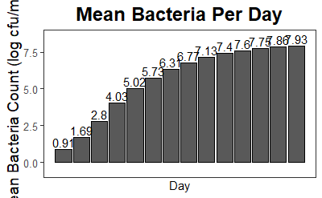

```r
#A ggplot Bar Chart
fig_ssc <- ggplot() + geom_bar(aes(y = Mean, x = day), data = mean_by_day,
                               stat = "identity", color = "black", position = "dodge")

#Add the number above the bar plot
fig_ssc <- fig_ssc + geom_text(data = mean_by_day,
            aes(x = day, y = Mean, label = round(Mean, 2)),
            position=position_dodge(width = 1),
            vjust=-0.25, size = 4)

##Some optional stuff that shows how to customize the look of the plot
fig_ssc <- fig_ssc + scale_fill_grey(start = 0.8, end = 0.0) + theme_bw() +
  theme(legend.title = element_blank(), legend.position = "right",
        plot.title = element_text(face = "bold", size = 18,hjust = 0.5),
        panel.grid.major.x = element_blank(),
        panel.grid.minor.x = element_blank(),
        panel.grid.major.y = element_blank(),
        panel.grid.minor.y = element_blank(),
        axis.text.x = element_text(size = 14 ),
        axis.text.y = element_text(size = 10),
        axis.title.y = element_text(size = 14),
        axis.ticks.x.bottom = element_blank())

## Set up the title of the graphs and the way the x and y axes are handled
fig_ssc <- fig_ssc + labs(y = "Mean Bacteria Count (log cfu/ml)", x = "Day" )+
        scale_x_discrete(breaks = seq(1, 14, 1)) +
        scale_y_continuous(limits = c(-1, 9), expand = c(0, 0)) +
        ggtitle("Mean Bacteria Per Day")

#type the name to display it
fig_ssc
```

- Plotting actual counts from day 7, 10, etc from VSL data
  - The actual counts came from VSL data and is in a separate CSV file that gets called in
  - Use this to create histograms to see what VSL data looks like

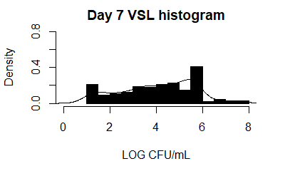

```r
#VSL Data for day 7 and day 10
day7andday10<-read.csv("Log microbial count__MCinput_021419.csv")

#create a histogram/distribution just for the VSL data
logday7<-day7andday10$LOG.D7
newlogday7<-as.numeric(logday7) #use the log day 7 column from VSL data
logday10<-day7andday10$LOG.D10
newlogday10<-as.numeric(logday10) #use the log day 10 column from VSL data

#histogram with proportions for day 7
hist(newlogday7, 10, col="black", main="Day 7 VSL histogram",
     xlab="LOG CFU/mL", xlim=c(0,8), ylim = c(0,0.8), freq = FALSE)
lines(density(na.omit(newlogday7)))
```

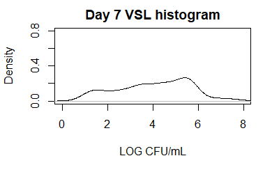

```r
# plot density plot for day 7
plot(density(na.omit(newlogday7)), main="Day 7 VSL histogram",
     xlab="LOG CFU/mL", xlim=c(0,8), ylim=c(0,0.8))
```

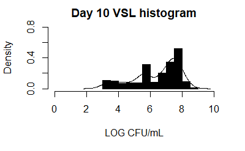

```r
#histogram with proportions for day 10
hist(newlogday10, 10, col="black", main="Day 10 VSL histogram",
     xlab="LOG CFU/mL", xlim=c(0,10), ylim = c(0,0.8), freq = FALSE)
lines(density(na.omit(newlogday10)))
```

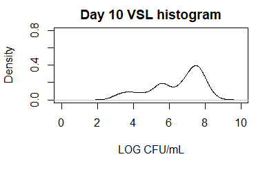

```r
# plot density plot for day 10
plot(density(na.omit(newlogday10)), main="Day 10 VSL histogram",
     xlab="LOG CFU/mL", xlim=c(0,10), ylim=c(0,0.8))
```

```r
shapiro.test(newlogday7)
```

```
    Shapiro-Wilk normality test

data:  newlogday7
W = 0.95472, p-value = 7.425e-09
```

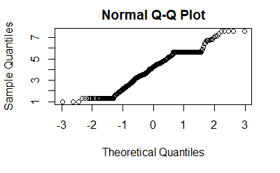

```r
qqnorm(newlogday7)
```

```r
shapiro.test(newlogday10)
```

```
    Shapiro-Wilk normality test

data:  newlogday10
W = 0.90155, p-value = 6.266e-15
```

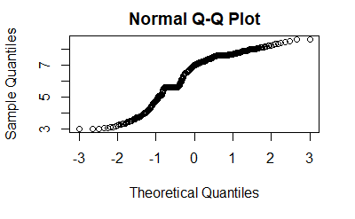

```r
qqnorm(newlogday10)
```

- Simulating data for day 7

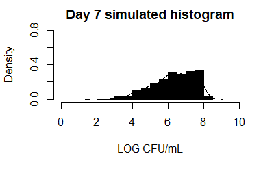

```r
#created a new table data2 just because I don't want to mess with original data
data2<-data

#Make a df only including day and count
data2_counts <- data2[c(4,5)]

#Make df of day 7 only
#Note: You want to change this to day==3 when the initial mean and SD is set using the day 7 data instead of initial
#should this be 6 since day initial is day 1????? or 7
day7counts<- data2_counts[data2_counts$day=="7",]

#only using the count data
day7counts_sim<-day7counts$count

#making a numeric factor
day7counts_sim<-as.numeric(day7counts_sim)

#histogram with simulated day 7
hist(day7counts_sim, 10, col="black", main="Day 7 simulated histogram",
     xlab="LOG CFU/mL", xlim=c(0,10), ylim = c(0,0.8), freq = FALSE)
lines(density(na.omit(day7counts_sim)))
```

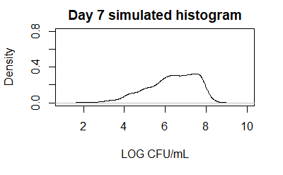

```r
#density plot with day 7 simulated
plot(density(na.omit(day7counts_sim)), main="Day 7 simulated histogram",
     xlab="LOG CFU/mL", xlim=c(1,10), ylim=c(0,0.8))
```

- Comparing simulated and VSL data for day 7

```r
#create a histogram with both the simulated and the VSL data
plot(density(na.omit(day7counts_sim)), main="Day 7 simulated vs VSL",
     xlab="LOG CFU/mL", xlim=c(0,10), ylim=c(0,0.8))
lines(density(na.omit(newlogday7)), col="blue")
legend('topright',  legend = c("simulated", "VSL"),
       lty=1, col=c('black', 'blue'), bty='n', cex=.75)

shapiro.test(day7counts_sim)
qqnorm(day7counts_sim)

wilcox.test(newlogday7, day7counts_sim, paired = FALSE)

p=ecdf(day7counts_sim)
p2=ecdf(newlogday7)
plot(p, verticals = TRUE, do.points=FALSE)
plot(p2, verticals = TRUE, do.points=FALSE, add=TRUE, col="blue")
```

[output not shown]

- Running Kolmogorov-Smirnov test for day 7
  - Purpose: Want to compare the distributions of the VSL versus simulated

```r
#perform Kolmogorov-Smirnov test
ks.test(day7counts_sim, newlogday7, alternative = c("two.sided"), exact = NULL)

#x <- day7counts_sim[!is.na(day7counts_sim)]
#n <- length(x)
#ks.test.critical.value(n, 0.95, alternative = "two.sided")

#install.packages("BoutrosLab.plotting.general")
#library(BoutrosLab.plotting.general)
#install.packages("KScorrect")

#calculating critical value
x <- day7counts_sim[!is.na(day7counts_sim)]
n <- length(x)
  y <- newlogday7[!is.na(newlogday7)]
  n.y <- length(y)

#5%level significance
a=1.35810
day7critvalue5<-1.35810*((n+n.y)/(n*n.y))^0.5
day7critvalue5

#10%level significance
a=1.22385
day7critvalue10<-1.22385*((n+n.y)/(n*n.y))^0.5
day7critvalue10


#20%level significance
a=1.07275
day7critvalue20<-1.07275*((n+n.y)/(n*n.y))^0.5
day7critvalue20


alternative <- "two.sided"
x <- day7counts_sim[!is.na(day7counts_sim)]
n <- length(x)
  y <- newlogday7[!is.na(newlogday7)]
  n.x <- as.double(n)
  n.y <- length(y)
  w <- c(x, y)
  z <- cumsum(ifelse(order(w) <= n.x, 1/n.x, -1/n.y))
  z <- z[c(which(diff(sort(w)) != 0), n.x + n.y)] #exclude ties
  STATISTIC <- switch(alternative, two.sided = max(abs(z)),
                      greater = max(z), less = -min(z))
  STATISTIC
```

[output not shown]

RANDOM BOXPLOT JUNK SAM WROTE, DON’T RUN THIS

```r
#boxplot of day 7 simulated histogram
boxplot(na.omit(day7counts_sim), ylab="LOG CFU/mL", ylim=c(2,10), main="Day 7 Simulated Boxplot")

#boxplot of day 7 VSL data histogram
boxplot(na.omit(newlogday7), ylab="LOG CFU/mL", ylim=c(0,8), main="Day 7 VSL data Boxplot")

#combining box plots AND making it horizontal
boxplot(na.omit(newlogday7), xlab="LOG CFU/mL", ylim=c(0,10), col="blue", main="Day 7 Combined Boxplot", horizontal = TRUE)
boxplot(na.omit(day7counts_sim), ylim=c(0,8), horizontal = TRUE, add = TRUE)
legend('topright',  legend = c("VSL", "simulated"),
       lty=1, col=c('blue', 'black'), bty='n', cex=.75)

#combine histogram with boxplot
#this doesn't work
plot(density(na.omit(day7counts_sim)), main="Day 7 simulated vs VSL",
     xlab="LOG CFU/mL", xlim=c(0,10), ylim=c(0,0.8))
lines(density(na.omit(newlogday7)), col="blue")
legend('topright',  legend = c("simulated", "VSL"),
       lty=1, col=c('black', 'blue'), bty='n', cex=.75)
boxplot(na.omit(day7counts_sim), ylim=c(0,8), horizontal = TRUE, add = TRUE)
```

- Simulating data for day 10

```r
#Make df of day 10 only
#Note: change this to day==4 when the initial mean and SD is set using the day 7 data instead of initial
day10counts<- data2_counts[data2_counts$day=="10",]

#only using the count data
day10counts_sim<-day10counts$count

#making a numeric factor
day10counts_sim<-as.numeric(day10counts_sim)

#day10factor
day10countfactor<-as.factor(day10counts_sim)
```

- Comparing simulated and VSL data for day 10

```r
#histogram with simulated day 10
hist(day10counts_sim, 10, col="black", main="Day 10 simulated histogram",
     xlab="LOG CFU/mL", xlim=c(0,10), ylim = c(0,0.8), freq = FALSE)
lines(density(na.omit(day10counts_sim)))

#plot with day 10 simulated histogram
plot(density(na.omit(day10counts_sim)), main="Day 10 simulated histogram",
     xlab="LOG CFU/mL", xlim=c(1,10), ylim=c(0,0.8))

#create a histogram with both the simulated and the VSL data
plot(density(na.omit(day10counts_sim)), main="Day 10 simulated vs VSL",
     xlab="LOG CFU/mL", xlim=c(0,10), ylim=c(0,1.2))
lines(density(na.omit(newlogday10)), col="blue")
legend('topright',  legend = c("simulated", "VSL"),
       lty=1, col=c('black', 'blue'), bty='n', cex=.75)
```

[output not shown]

- Comparing day 7 and day 10 concentrations for VSL and simulated

```r
# plot density plot of day 10 and day 7
plot(density(na.omit(newlogday10)), main="Day 7 vs 10 VSL/Simulated histogram",
     xlab="LOG CFU/mL", xlim=c(-1,10), ylim=c(0,1.0))
lines(density(na.omit(newlogday7)), col="red", lty=1) #VSL day 7 data
lines(density(na.omit(day10counts_sim)), col="black", lty=2) #simulated day 10 data
lines(density(na.omit(day7counts_sim)), col="red", lty=2) #simulated day 10 data
legend('topright',  legend = c("7 VSL", "10 VSL", "7 sim", "10 sim"),
       lty=c(1,1,2,2), col=c('red', 'black','red', 'black'), bty='n', cex=.55)


q=ecdf(day10counts_sim)
q2=ecdf(newlogday10)
plot(q, verticals = TRUE, do.points=FALSE)
plot(q2, verticals = TRUE, do.points=FALSE, add=TRUE, col="blue")
```

[output not shown]

- Running Kolmogorov-Smirnov test for day 10
  - Purpose: Want to compare the distributions of the VSL versus simulated

```r
ks.test(day10counts_sim, newlogday10, alternative = c("two.sided"), exact = NULL)


#calculating critical value
x <- day10counts_sim[!is.na(day10counts_sim)]
n <- length(x)
  y <- newlogday10[!is.na(newlogday10)]
  n.y <- length(y)

a=1.36
day10critvalue<-1.36*((n+n.y)/(n*n.y))^0.5
day10critvalue

#5%level significance
a=1.35810
day10critvalue5<-1.35810*((n+n.y)/(n*n.y))^0.5
day10critvalue5

#10%level significance
a=1.22385
day10critvalue10<-1.22385*((n+n.y)/(n*n.y))^0.5
day10critvalue10


#20%level significance
a=1.07275
day10critvalue20<-1.07275*((n+n.y)/(n*n.y))^0.5
day10critvalue20
```

[output not shown]

DONT RUN THIS

```r
#this is with day 7 set as the initial to extrapolate day 10
length(which(subset(day10counts_sim, day10counts_sim$day == 4)$count>6))/length(subset(day10counts_sim, day10counts_sim$day == 4)$count)
#length(which(subset(data, data$day == 10)$count>6))/length(subset(data, data$day == 10)$count)
```

- Calculate proportion of samples that have spoiled
  - Set count to desired log value
  - Ex: If I want to see proportions of samples that reach 1,000,000 CFU/mL, set count>6
  - Ex: If I wanted to see proportions of samples that reach 20,000 CFU/mL, set count>4.3
  - Proportion= samples that reach X log for Y day/ total samples for Y day

```r
length(which(subset(data, data$day == 7)$count>4.3))/length(subset(data, data$day == 7)$count)
length(which(subset(data, data$day == 10)$count>4.3))/length(subset(data, data$day == 10)$count)
length(which(subset(data, data$day == 14)$count>4.3))/length(subset(data, data$day == 14)$count)
```

[output not shown]

- Calculate the spoilage per day
  - You can change the starting and end day by changing days
  - Ex: If you want to look at spoilage from days 1 to 14, set days <- seq(1, 14, 1)
  - Ex: If you want to look at spoilage from days 3 to 17, days <- seq(3, 17, 1)
  - The third one is because you want the days to increase by 1

```r
#create a dataframe of day and a vector that will eventually hold the percentage of spoiled samples
#mode=logical means you set it to false
days <- seq(1, 14, 1)
spoiled <- vector(mode = "logical", length(days))
spoiled_by_day <- data.frame(days, spoiled)

#now fill in the empty vector with the proper percentage
#gives you percentage of days greater than 4.3 log
for (d in days) {
  numerator <-   length(which(subset(data, data$day == d)$count>4.3))
  denominator <- length(subset(data, data$day == d)$count)

  spoiled_by_day[spoiled_by_day$days==d,]$spoiled <- numerator / denominator * 100
}

spoiled_by_day$days <- factor(spoiled_by_day$days)
```

```r
#TAKE THIS OUT IF IT THIS DOESN'T WORK
fig_SBD <- ggplot() + geom_bar(aes(y = spoiled_by_day$spoiled, x = spoiled_by_day$days), data = spoiled_by_day,
                               stat = "identity", color = "black", position = "dodge")

#print to see what the plot looks like
fig_SBD

#Add the number above the bar plot
fig_SBD <- fig_SBD + geom_text(data = spoiled_by_day,
                               aes(x = spoiled_by_day$days, y = spoiled_by_day$spoiled, label = round(spoiled_by_day$spoiled, 2)),
                               position=position_dodge(width = 1),
                               vjust=-0.25, size = 4)

fig_SBD

##Some optional stuff that shows how to customize the look of the plot
fig_SBD <- fig_SBD + scale_fill_grey(start = 0.8, end = 0.0) + theme_bw() +
  theme(legend.title = element_blank(), legend.position = "right",
       plot.title = element_text(face = "bold", size = 18,hjust = 0.5),
       panel.grid.major.x = element_blank(),
       panel.grid.minor.x = element_blank(),
      panel.grid.major.y = element_blank(),
      panel.grid.minor.y = element_blank(),
        axis.text.x = element_text(size = 14 ),
        axis.text.y = element_text(size = 10),
       axis.title.y = element_text(size = 14),
        axis.ticks.x.bottom = element_blank())

fig_SBD
## Set up the title of the graphs and the way the x and y axes are handled
fig_SBD <- fig_SBD + labs(y = "Percentage > 4.3log", x = "Day" )+
  scale_x_discrete(breaks = seq(1, 14, 1), labels=seq(1, 14, 1)) +
  scale_y_continuous(limits = c(0, 100), expand = c(0, 0)) +
  ggtitle("Percent of samples spoiled by day")

#type the name to display it
fig_SBD
```

[output not shown]

- Creating plots when doing sensitivity analysis
  - Purpose: This will print out the PDF version of the plot when you change a parameter

```r
pdf(file='plot_original_fixed_frequency13decreaseto0_summary.pdf')
fig_SBD <- ggplot() + geom_bar(aes(y = spoiled_by_day$spoiled, x = spoiled_by_day$days), data = spoiled_by_day,
                               stat = "identity", color = "black", position = "dodge")+
  geom_text(data = spoiled_by_day,
              aes(x = spoiled_by_day$days, y = spoiled_by_day$spoiled, label = round(spoiled_by_day$spoiled, 2)),
              position=position_dodge(width = 1),
              vjust=-0.25, size = 4)+
  labs(y = "Percentage > 4.3log", x = "Day" )+
  scale_x_discrete(breaks = seq(1, 14, 1), labels=seq(1, 14, 1)) +
  scale_y_continuous(limits = c(0, 100), expand = c(0, 0)) +
  ggtitle("Percent of samples spoiled by day")

#print to see what the plot looks like
fig_SBD

dev.off()
```

More random plots, DON’T RUN

```r
  #Simple scatter plot
  plot(spoiled_by_day$days, spoiled_by_day$spoiled)
  #line plot
  #type = L MAKES IT A LINE PLOT
  plot(spoiled_by_day$days, spoiled_by_day$spoiled, type = 'l')
  #bar plot
  barplot(spoiled_by_day$spoiled, names.arg = spoiled_by_day$days,
          ylim = c(0, 100))

  #bar plot with more options
  xbarplot<-barplot(spoiled_by_day$spoiled, names.arg = spoiled_by_day$days,
          xlab = "Day",
          ylab = "Percentage > 4.3",
          ylim = c(0, 100),  xlim=c(1,14),
          main = "Percent of samples spoiled by day")

  xbarplot

  #only works for GG plot, can't combine diff codes
  #text(x = xbarplot, y = spoiled_by_day, label = spoiled_by_day, pos = 3, cex = 0.8, col = "red")

  #xbarplot <- xbarplot + geom_text(data = spoiled_by_day,
                                # aes(x = day, y = spoiled_by_day, label = spoiled_by_day),
                                # position=position_dodge(width = 1),
                                # vjust=-0.25, size = 4)
 # xbarplot

  #same as a horizontal plot
  barplot(spoiled_by_day$spoiled, names.arg = spoiled_by_day$days,
          horiz = TRUE,
          ylab = "Day",
          xlab = "Percentage > 4.3",
          xlim = c(0, 50),
          main = "Percent of samples spoiled by day")
```